# Week 4 Cluster Analysis

20 September, 2019

## Overview of the Topics

- Basic concepts of cluster analysis
- KMeans algorithm
- Hierarchical Agglomerative Clustering (HAC)
- Evaluation of the clustering outputs
- Hyperparameters of the clustering algorithms
- Visualize clustering output: PCA (Principal Component Analysis)
- R/Python demo of the cluster analysis

## Motivations

- Identify grouping structure of data so that objects within the same group are closer (more similar) to each other while farther (less similar) to those in different groups
  - Various distance/proximity functions
  - intra-cluster distance vs. inter-cluster distance
- Unsupervised learning: used for data exploration
  - Can also be adapted for supervised learning purpose
- Types of cluster analysis
  - Partitional vs. Hierarchical: one point can belong to one or multiple clusters
  - kmeans algorithm vs. HAC (Hierarchical Agglomerative Clustering) algorithm

## Partitional vs. Hierarchical Clustering

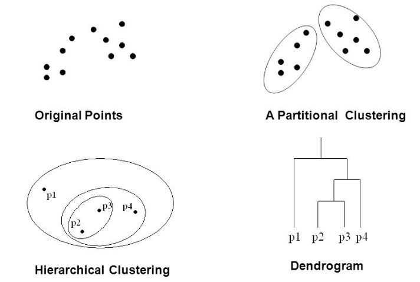

## Major Applications of Cluster Analysis

- Data sampling: use centroid as the representative samples
  - Centroid: center of mass which is caculated as the (arithmetic) mean of all the data points in the same cluster (separately for each dimension)
- Marketing segmentation analysis: help marketers segment their customer bases and develop targeted marketing programs
- Insurance: identify groups of motor insurance policy holders with a higher average claim cost
- Microarray analysis for biomedical research: A high throughput technology which allows testing thousand of genes simultaneously in different disease states

## Distance Functions

- Clustering is based on *distance*. How to measure it?
- Minkowski distance: distance between two vectors is the norm of their difference; \(L_p\) norm, \[ d_{minkowski} = (\sum_{i=1}^n |x_i-y_i|^p)^\frac{1}{p} \]
- Manhattan distance: \(L_1\) norm \[ d_{manhattan} = \sum_{i=1}^n |(x_i-y_i)| \]
- Euclidean distance: \(L_2\) norm \[ d_{euclidean}(x, y) = \sqrt{\sum_{i = 1}^n (x_i - y_i)^2} \]

## Additional Distance Functions

- Cosine Similarity \[ cos\theta = \frac{\vec{a}\cdot \vec{b}}{\lVert{\vec{a}}\rVert\lVert{\vec{b}\rVert}} \]
  - Magnitude of vectors does not matter but the orientation
  - Used often in measuring similarities between different documents, such as text mining and NLP

## Model Preprocessing

- Transformation of categorical attributes into numerical attributes (opposite to association rule mining)
- Data standardization, normalization, rescale
  - Applies to all algorithms based on distance: KNN, SVM, etc.
- Remove or impute missing values
- Detection and removal of noisy data and *outliers*

## Animation of How kmeans Algorithm works

[figure not shown]

## Summary of kmeans

- Kmeans
  - Randomly assign k centroids
  - Assign all data points to their closest centroids
  - Update centroid assignments
  - Repeat the previous two steps until centroids are stable

## Cluster Validity Evaluation

- SSE (Sum of Square Error): most common measure \[ SSE = \sum_{i=1}^K\sum_{x\in C_i}dist^2(m_i, x) \]
  - Cluster cohesion
  - SSE is a monotonically decreasing function of number of clusters. Therefore it can be used to compare cluster performance only for similar number of clusters

## Objective Function for Kmeans Clustering: SSE

- Also known as loss/cost function
- Goal of Kmeans method is to
  - Minimize SSE of within-cluster variance
  - Same as the sum of Euclidean distance between all data points with their respective cluster centroids
- Therefore no needs to set the distance function for Kmeans method

## Hierarchical Agglomerative Clustering

- Treat each data point as a cluster
- Compute the pairwise distance matrix for all clusters
- Merge closer clusters into a larger one and update the distance matrix
- Keep repeating the previous step until there is only one cluster left
- Opposite: HDC (Hierarchical Divisive Clustering)

## Defintion of Inter-Cluster Distance

- Single linkage: minimal pairwise distance between data points belonging to different clusters
- Complete linkage: maximal pairwise distance between data points belonging to different clusters
- Average linkage method: average pairwise distance between all data points belonging to different clusters
- Centroid linkage method: pairwise distance between centroids of different clusters

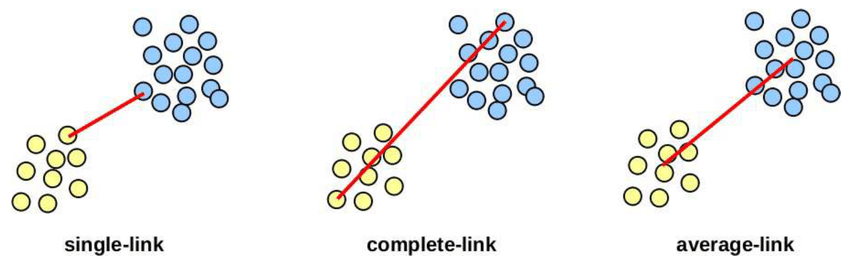

## Model Parameters

- Algorithm-specific
  - kmeans
    - Number of clusters: Elbow method to estimate
    - Initial choice of cluster centers (centroid)
      - Kmeans method is guaranteed to converge but not guaranteed to converge to global optimial
    - Maximal number of repeats
  - Hierarchical clustering
    - Distance function between data points
    - Definition of intercluster distance: single vs. complete vs. average vs. centroid linkage
    - Number of clusters to output (needed after clustering)

## Comparison Between Kmeans and HAC (1)

- Objective function
  - Kmeans: sum of squared difference between data points and their respective centroid (within SS)
  - HAC: no objective function, greedy algorithm
- Parameter setting
  - Kmeans: need to specify number of clusters prior to running aglorithm
  - HAC: no need to choose number of clusters a priori; can choose after fact
- Performance
  - Kmeans: Fast with linear time complexity \(O(N)\) (\(N\): number of data points)
  - HAC: Slow with quadratic complexity \(O(N^2)\)
  - Hybrid approach: run Kmeans first to reduce dataset size and then HAC to cluster

## Comparison Between Kmeans and HAC (2)

- Structure of clusters
  - Kmeans: works best with sphere clusters with similar size
  - HAC: works with clusters of different size and shape
    - Depending on inter-cluster distance definition
    - Single-linkage method: clusters of different size; prone to outliers
    - Complete-linkage method: clusters of similar size; prone to outliers
    - Average/Centroid linkage: resist outliers
  - Both methods couldn’t deal well with clusters of different densities: DBScan
- Both methods mostly work with numerical attributes only (contrary to association rule mining)

## Principal Component Analysis (PCA): Cluster Visualization

- Dimension reduction: only pick those first few columns to reduce number of attributes (unrelated to each out)
- High dimensional data isualize: plot inlower dimensional space defined by principal components (PC1 and PC2)
- Benefits
  - Breakdown multicolinearity among original attributes and the new reconstructed dataset (with PCs as columns) have all the columns un-correlated
    - Loading factors gives us direction upon which the projected data points vary the most

## Demo Dataset: USArrests

- Crime dataset:
  - Arrests per 100,000 residents for assault, murder, and rape in each of the 50 US states in 1973
  - Percent of the population living in urban areas

```r
library(datasets)
str(USArrests)
```

```
## 'data.frame':    50 obs. of  4 variables:
##  $ Murder  : num  13.2 10 8.1 8.8 9 7.9 3.3 5.9 15.4 17.4 ...
##  $ Assault : int  236 263 294 190 276 204 110 238 335 211 ...
##  $ UrbanPop: int  58 48 80 50 91 78 77 72 80 60 ...
##  $ Rape    : num  21.2 44.5 31 19.5 40.6 38.7 11.1 15.8 31.9 25.8 ...
```

```r
row.names(USArrests)
```

```
##  [1] "Alabama"        "Alaska"         "Arizona"        "Arkansas"
##  [5] "California"     "Colorado"       "Connecticut"    "Delaware"
##  [9] "Florida"        "Georgia"        "Hawaii"         "Idaho"
## [13] "Illinois"       "Indiana"        "Iowa"           "Kansas"
## [17] "Kentucky"       "Louisiana"      "Maine"          "Maryland"
## [21] "Massachusetts"  "Michigan"       "Minnesota"      "Mississippi"
## [25] "Missouri"       "Montana"        "Nebraska"       "Nevada"
## [29] "New Hampshire"  "New Jersey"     "New Mexico"     "New York"
## [33] "North Carolina" "North Dakota"   "Ohio"           "Oklahoma"
## [37] "Oregon"         "Pennsylvania"   "Rhode Island"   "South Carolina"
## [41] "South Dakota"   "Tennessee"      "Texas"          "Utah"
## [45] "Vermont"        "Virginia"       "Washington"     "West Virginia"
## [49] "Wisconsin"      "Wyoming"
```

## Data Preprocess

```r
sum(!complete.cases(USArrests))
```

```
## [1] 0
```

```r
summary(USArrests)
```

```
##      Murder          Assault         UrbanPop          Rape
##  Min.   : 0.800   Min.   : 45.0   Min.   :32.00   Min.   : 7.30
##  1st Qu.: 4.075   1st Qu.:109.0   1st Qu.:54.50   1st Qu.:15.07
##  Median : 7.250   Median :159.0   Median :66.00   Median :20.10
##  Mean   : 7.788   Mean   :170.8   Mean   :65.54   Mean   :21.23
##  3rd Qu.:11.250   3rd Qu.:249.0   3rd Qu.:77.75   3rd Qu.:26.18
##  Max.   :17.400   Max.   :337.0   Max.   :91.00   Max.   :46.00
```

```r
df <- na.omit(USArrests)
df <- scale(df, center = T, scale = T)
summary(df)
```

```
##      Murder           Assault           UrbanPop             Rape
##  Min.   :-1.6044   Min.   :-1.5090   Min.   :-2.31714   Min.   :-1.4874
##  1st Qu.:-0.8525   1st Qu.:-0.7411   1st Qu.:-0.76271   1st Qu.:-0.6574
##  Median :-0.1235   Median :-0.1411   Median : 0.03178   Median :-0.1209
##  Mean   : 0.0000   Mean   : 0.0000   Mean   : 0.00000   Mean   : 0.0000
##  3rd Qu.: 0.7949   3rd Qu.: 0.9388   3rd Qu.: 0.84354   3rd Qu.: 0.5277
##  Max.   : 2.2069   Max.   : 1.9948   Max.   : 1.75892   Max.   : 2.6444
```

```r
apply(USArrests, 2, sd)
```

```
##    Murder   Assault  UrbanPop      Rape
##  4.355510 83.337661 14.474763  9.366385
```

```r
apply(USArrests, 2, mean)
```

```
##   Murder  Assault UrbanPop     Rape
##    7.788  170.760   65.540   21.232
```

```r
apply(df, 2, sd)
```

```
##   Murder  Assault UrbanPop     Rape
##        1        1        1        1
```

```r
apply(df, 2, mean)
```

```
##        Murder       Assault      UrbanPop          Rape
## -7.663087e-17  1.112408e-16 -4.332808e-16  8.942391e-17
```

## Distance function and visualization

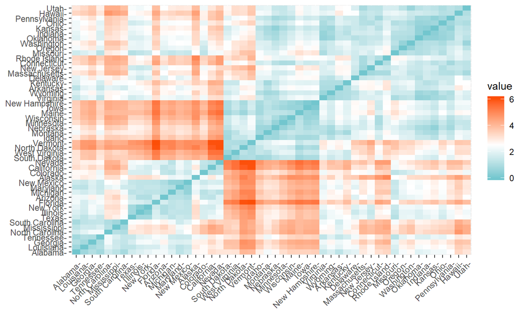

```r
library(factoextra)
distance <- get_dist(df, method = "euclidean")
fviz_dist(distance, gradient = list(low = "#00AFBB", mid = "white", high = "#FC4E07"))
```

## kmeans Function

```r
km_output <- kmeans(df, centers = 2, nstart = 25, iter.max = 100, algorithm = "Hartigan-Wong")
str(km_output)
```

```
## List of 9
##  $ cluster     : Named int [1:50] 1 1 1 2 1 1 2 2 1 1 ...
##   ..- attr(*, "names")= chr [1:50] "Alabama" "Alaska" "Arizona" "Arkansas" ...
##  $ centers     : num [1:2, 1:4] 1.005 -0.67 1.014 -0.676 0.198 ...
##   ..- attr(*, "dimnames")=List of 2
##   .. ..$ : chr [1:2] "1" "2"
##   .. ..$ : chr [1:4] "Murder" "Assault" "UrbanPop" "Rape"
##  $ totss       : num 196
##  $ withinss    : num [1:2] 46.7 56.1
##  $ tot.withinss: num 103
##  $ betweenss   : num 93.1
##  $ size        : int [1:2] 20 30
##  $ iter        : int 1
##  $ ifault      : int 0
##  - attr(*, "class")= chr "kmeans"
```

```r
names(km_output)
```

```
## [1] "cluster"      "centers"      "totss"        "withinss"
## [5] "tot.withinss" "betweenss"    "size"         "iter"
## [9] "ifault"
```

```r
typeof(km_output)
```

```
## [1] "list"
```

```r
length(km_output)
```

```
## [1] 9
```

```r
km_output$cluster
```

```
##        Alabama         Alaska        Arizona       Arkansas     California
##              1              1              1              2              1
##       Colorado    Connecticut       Delaware        Florida        Georgia
##              1              2              2              1              1
##         Hawaii          Idaho       Illinois        Indiana           Iowa
##              2              2              1              2              2
##         Kansas       Kentucky      Louisiana          Maine       Maryland
##              2              2              1              2              1
##  Massachusetts       Michigan      Minnesota    Mississippi       Missouri
##              2              1              2              1              1
##        Montana       Nebraska         Nevada  New Hampshire     New Jersey
##              2              2              1              2              2
##     New Mexico       New York North Carolina   North Dakota           Ohio
##              1              1              1              2              2
##       Oklahoma         Oregon   Pennsylvania   Rhode Island South Carolina
##              2              2              2              2              1
##   South Dakota      Tennessee          Texas           Utah        Vermont
##              2              1              1              2              2
##       Virginia     Washington  West Virginia      Wisconsin        Wyoming
##              2              2              2              2              2
```

```r
km_output$centers
```

```
##      Murder    Assault   UrbanPop       Rape
## 1  1.004934  1.0138274  0.1975853  0.8469650
## 2 -0.669956 -0.6758849 -0.1317235 -0.5646433
```

```r
km_output$size
```

```
## [1] 20 30
```

## Loss Function: Sum of Square Error

```r
km_output$totss
```

```
## [1] 196
```

```r
km_output$withinss
```

```
## [1] 46.74796 56.11445
```

```r
km_output$betweenss
```

```
## [1] 93.1376
```

```r
sum(c(km_output$withinss, km_output$betweenss))
```

```
## [1] 196
```

```r
cohesion <- sum(km_output$withinss)/km_output$totss
cohesion
```

```
## [1] 0.5248082
```

## Visualize Cluster Assignment

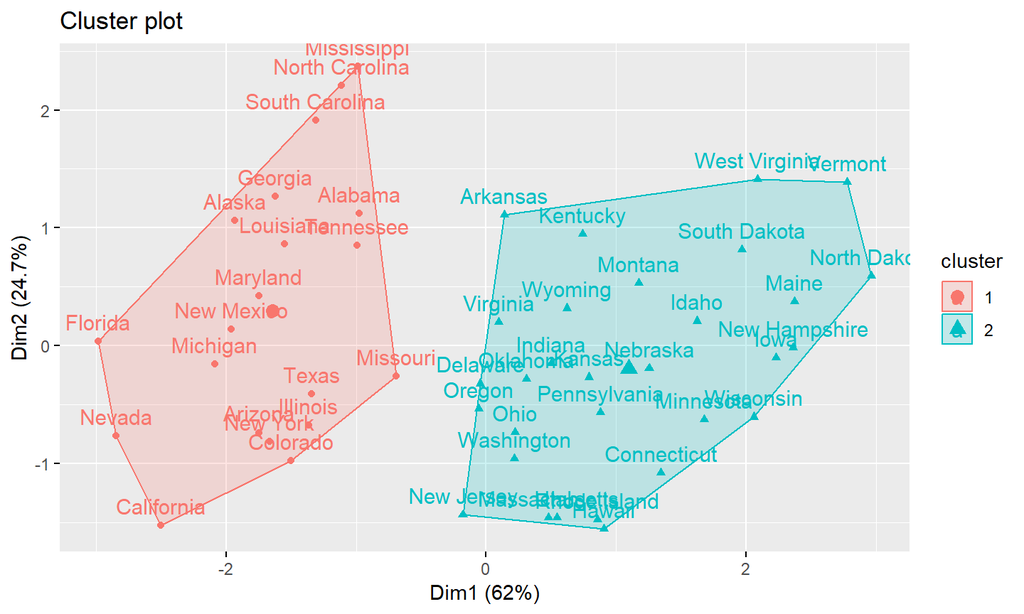

```r
fviz_cluster(km_output, data = df)
```

## PCA Analysis

```r
pca <- prcomp(USArrests, scale. = T, center = T)
pca$sdev
```

```
## [1] 1.5748783 0.9948694 0.5971291 0.4164494
```

```r
pca$rotation
```

```
##                 PC1        PC2        PC3         PC4
## Murder   -0.5358995  0.4181809 -0.3412327  0.64922780
## Assault  -0.5831836  0.1879856 -0.2681484 -0.74340748
## UrbanPop -0.2781909 -0.8728062 -0.3780158  0.13387773
## Rape     -0.5434321 -0.1673186  0.8177779  0.08902432
```

```r
summary(pca)
```

```
## Importance of components:
##                           PC1    PC2     PC3     PC4
## Standard deviation     1.5749 0.9949 0.59713 0.41645
## Proportion of Variance 0.6201 0.2474 0.08914 0.04336
## Cumulative Proportion  0.6201 0.8675 0.95664 1.00000
```

## PCA Analysis (2)

```r
pcs <- as.data.frame(predict(pca, newdata = USArrests))
head(pcs, 5)
```

```
##                   PC1        PC2         PC3        PC4
## Alabama    -0.9756604  1.1220012 -0.43980366  0.1546966
## Alaska     -1.9305379  1.0624269  2.01950027 -0.4341755
## Arizona    -1.7454429 -0.7384595  0.05423025 -0.8262642
## Arkansas    0.1399989  1.1085423  0.11342217 -0.1809736
## California -2.4986128 -1.5274267  0.59254100 -0.3385592
```

```r
cov(pcs) ## covariance is zero
```

```
##               PC1           PC2           PC3           PC4
## PC1  2.480242e+00 -3.812359e-16  1.126674e-16  1.778258e-17
## PC2 -3.812359e-16  9.897652e-01 -2.024956e-16  9.907132e-17
## PC3  1.126674e-16 -2.024956e-16  3.565632e-01 -1.564569e-16
## PC4  1.778258e-17  9.907132e-17 -1.564569e-16  1.734301e-01
```

## Recreate Cluster Assignment with PCA

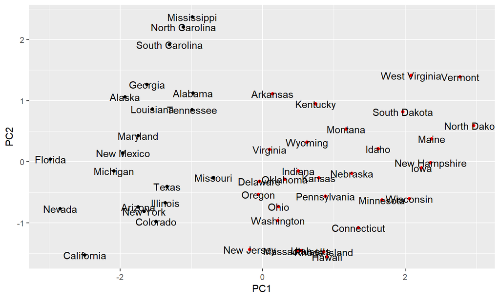

```r
cluster <- km_output$cluster
pcs$cluster <- cluster[match(rownames(pcs), names(cluster))]
library(ggplot2)
ggplot(pcs, aes(x = PC1, y = PC2)) +
  geom_point(col=cluster) +
  geom_text(label=rownames(pcs))
```

## Visual Cluster Assignment on Map (1)

```r
cluster_df <- data.frame(state = tolower(row.names(USArrests)),
                         cluster = unname(km_output$cluster))
library(maps)
states <- map_data("state")
states %>%
  left_join(cluster_df, by = c("region" = "state")) %>%
  ggplot() +
  geom_polygon(aes(x = long, y = lat, fill = as.factor(cluster), group = group),
               color = "white") +
  coord_fixed(1.3) +
  guides(fill = F) +
  theme_bw() +
  theme(panel.grid.major = element_blank(), panel.grid.minor = element_blank(),
        panel.border = element_blank(),
        axis.line = element_blank(),
        axis.text = element_blank(),
        axis.ticks = element_blank(),
        axis.title = element_blank())
```

## Visual Cluster Assignment on Map (2)

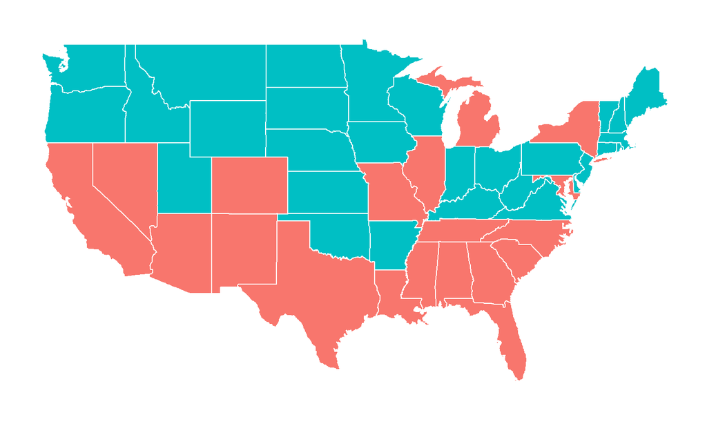

## Elbow method to decide Optimal Number of Clusters (1)

```r
set.seed(8)
wss <- function(k){
  return(kmeans(df, k, nstart = 25)$tot.withinss)
}

k_values <- 1:15

wss_values <- purrr::map_dbl(k_values, wss)

plot(x = k_values, y = wss_values,
     type = "b", frame = F,
     xlab = "Number of clusters K",
     ylab = "Total within-clusters sum of square")
```

## Elbow method to decide Optimal Number of Clusters (2)

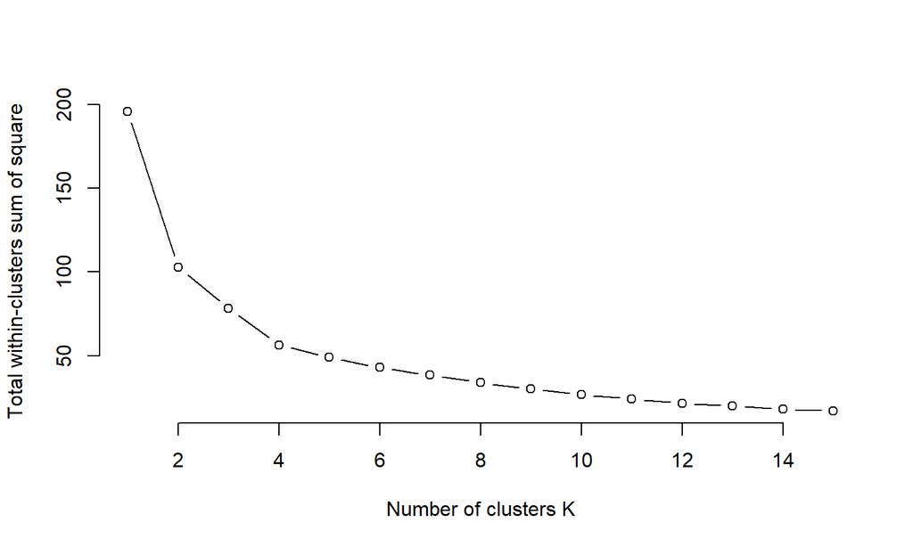

## Hierarchical Clustering

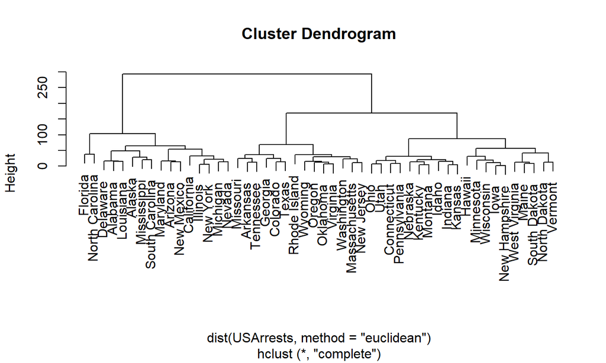

```r
hac_output <- hclust(dist(USArrests, method = "euclidean"), method = "complete")
plot(hac_output)
```

## Ouput Desirable Number of Clusters After Modeling

```r
hac_cut <- cutree(hac_output, 2)

for (i in 1:length(hac_cut)){
  if(hac_cut[i] != km_output$cluster[i]) print(names(hac_cut)[i])
}
```

```
## [1] "Colorado"
## [1] "Delaware"
## [1] "Georgia"
## [1] "Missouri"
## [1] "Tennessee"
## [1] "Texas"
```

## Cluster Analysis in Python

## Import Libraries for Analysis

```python
import pandas as pd
import numpy as np
import matplotlib.pyplot as plt
from sklearn import preprocessing
import seaborn as sns
from scipy.spatial import distance_matrix
from sklearn.cluster import KMeans
```

## Data Preprocessing

```python
USArrest = r.USArrests
USArrest.isnull().sum(axis=0)
```

```
## Murder      0
## Assault     0
## UrbanPop    0
## Rape        0
## dtype: int64
```

```python
min_max_scaler = preprocessing.MinMaxScaler()
np_scaled = min_max_scaler.fit_transform(USArrest)
df_normalized = pd.DataFrame(np_scaled, columns=USArrest.columns, index=USArrest.index)
df_normalized.describe()
```

```
##           Murder    Assault   UrbanPop       Rape
## count  50.000000  50.000000  50.000000  50.000000
## mean    0.420964   0.430685   0.568475   0.360000
## std     0.262380   0.285403   0.245335   0.242025
## min     0.000000   0.000000   0.000000   0.000000
## 25%     0.197289   0.219178   0.381356   0.200904
## 50%     0.388554   0.390411   0.576271   0.330749
## 75%     0.629518   0.698630   0.775424   0.487726
## max     1.000000   1.000000   1.000000   1.000000
```

## Visualize the Data (Codes)

```python
dist_matrix = pd.DataFrame(distance_matrix(df_normalized.values,
                           df_normalized.values, p=2),
                           index=df_normalized.index,
                           columns=df_normalized.index)
f, ax = plt.subplots(figsize=(11, 9))
sns.heatmap(dist_matrix, vmax=.5, center=0, square=True,
            linewidths=.5, cbar_kws={"shrink": .5})
```

## Visualize the Data (Output)

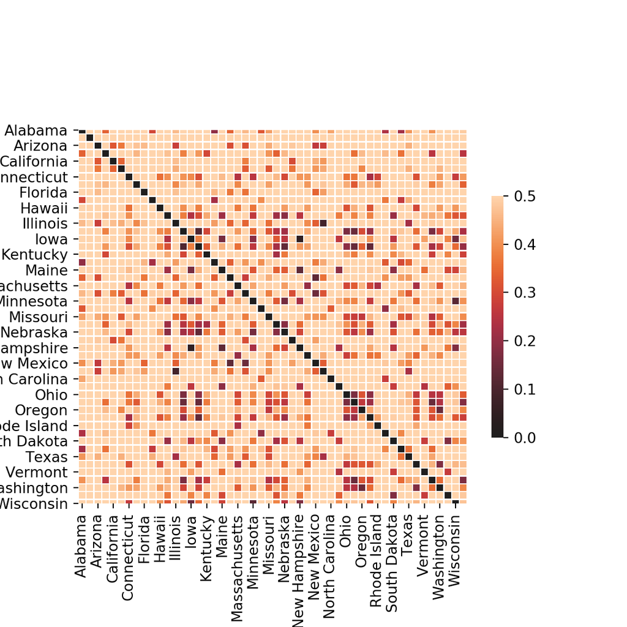

## KMeans Clustering using *sklearn*

```python
kmeans = KMeans(n_clusters=2, n_init=25, max_iter=100, random_state=6)
kmeans.fit(df_normalized)
```

```
## KMeans(algorithm='auto', copy_x=True, init='k-means++', max_iter=100,
##        n_clusters=2, n_init=25, n_jobs=None, precompute_distances='auto',
##        random_state=6, tol=0.0001, verbose=0)
```

```python
kmeans.__dict__.keys()
```

```
## dict_keys(['n_clusters', 'init', 'max_iter', 'tol', 'precompute_distances', 'n_init', 'verbose', 'random_state', 'copy_x', 'n_jobs', 'algorithm', 'cluster_centers_', 'labels_', 'inertia_', 'n_iter_'])
```

```python
kmeans.labels_
```

```
## array([1, 1, 1, 0, 1, 1, 0, 0, 1, 1, 0, 0, 1, 0, 0, 0, 0, 1, 0, 1, 0, 1,
##        0, 1, 1, 0, 0, 1, 0, 0, 1, 1, 1, 0, 0, 0, 0, 0, 0, 1, 0, 1, 1, 0,
##        0, 0, 0, 0, 0, 0])
```

## Elbow Method (Codes)

```python
from scipy.spatial.distance import cdist
distortions = []
K = range(1, 10)
for k in K:
    kmeanModel = KMeans(n_clusters=k).fit(dist_matrix)
    kmeanModel.fit(dist_matrix)
    distortions.append(sum(np.min(cdist(dist_matrix, kmeanModel.cluster_centers_, 'euclidean'), axis=1)) / dist_matrix.shape[0])

plt.plot(K, distortions, 'bx-')
plt.xlabel('k')
plt.ylabel('Distortion')
plt.title('The Elbow Method to Identify Optimal k')
plt.show()
```

## Elbow Method (Output)

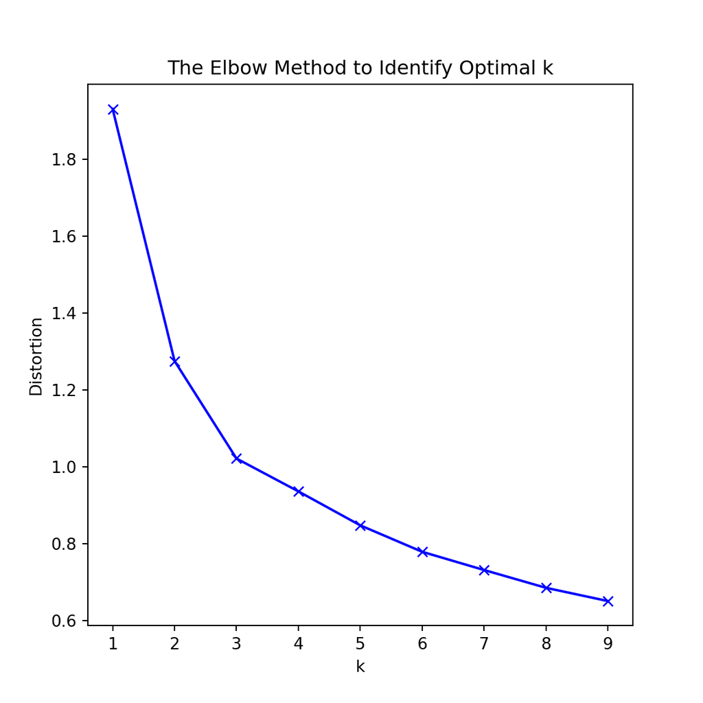

## Create Dendrogram (Codes)

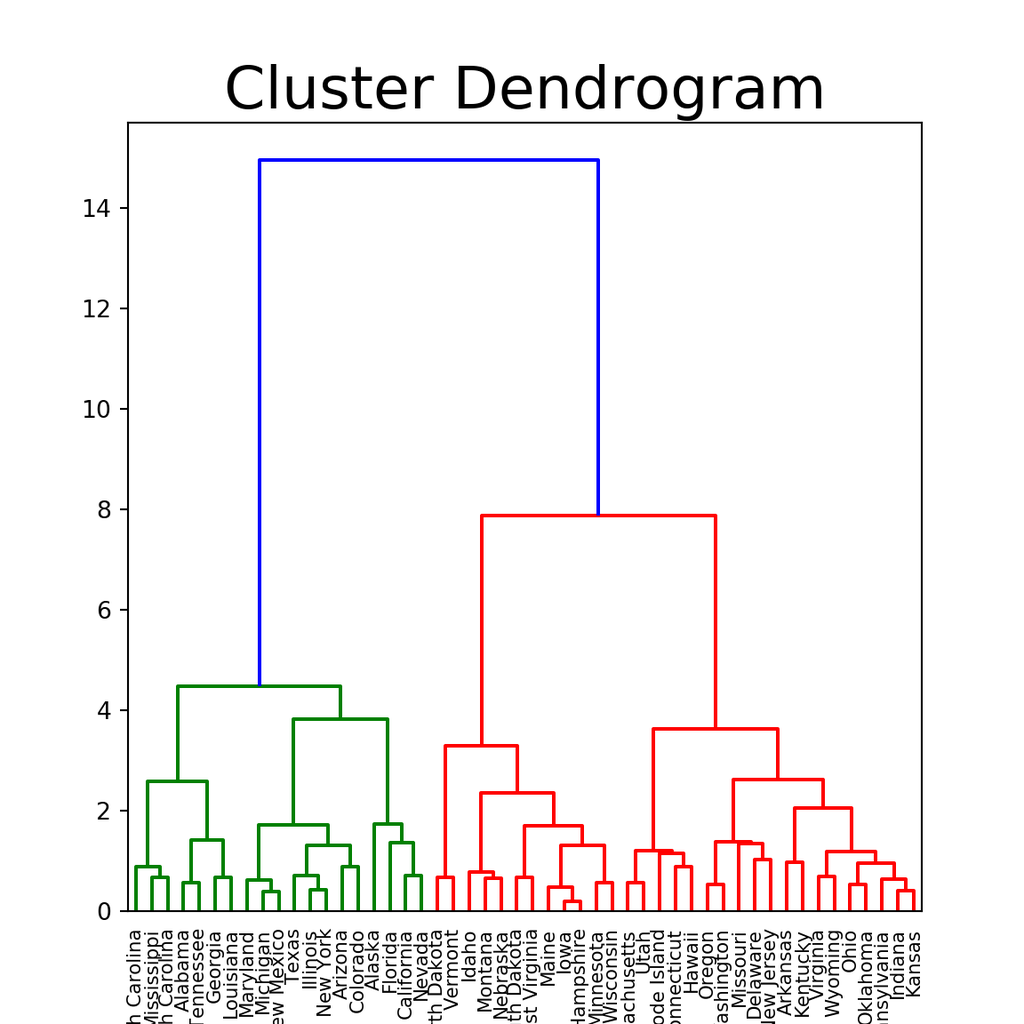

```python
from scipy.cluster.hierarchy import ward, dendrogram

linkage_matrix = ward(dist_matrix)

fig, ax = plt.subplots(figsize=(20, 10))
ax.grid(False)
ax.set_title('Cluster Dendrogram', fontsize = 25)
ax = dendrogram(linkage_matrix, orientation='top', labels=dist_matrix.index)
plt.xticks(fontsize=15)
plt.show()
```